# Hour 1 — EDA: Beyoncé vs Taylor Swift Lyrics

Who uses which words? David Robinson’s analysis, extended | TheDataShrink™

Author

TheDataShrink™

Published

April 18, 2026

**TheDataShrink™ — Data stories worth sharing.**

Episode 008 · Text Analysis · CONCEPT_INDEX.md

**Atomic Concepts in this episode**

`tokenization_pipeline` · `tf_idf_comparison` · `log_odds_ratio` · `multi_table_join` · `pivot_reshape` · `fct_reorder_stat` · `reorder_within_facets` · `grouped_summary_ggplot` · `scales_axis_labels` · `theme_set_global`

**FAILS WHEN**

- Text is multilingual without language detection
- Groups are not mutually exclusive (a song appears in both corpora)
- Stopword list doesn’t match the domain (lyrics use “ah”, “uh” as meaningful filler)

**WORKS WHEN**

- Two clearly distinct groups with long-form text
- Question is exploratory — what makes each voice unique?
- Audience recognises the artists (context amplifies insight)

## 1 Setup

```r
library(tidyverse)
library(tidytext)
library(tidylo)
library(scales)
library(lubridate)
library(ggrepel)
library(janitor)
theme_set(theme_light())

DATA <- here::here("tidytuesday/data/2020/2020-09-29")
```

## 2 Load data

```r
beyonce_lyrics      <- read_csv(file.path(DATA, "beyonce_lyrics.csv"),
                                show_col_types = FALSE)
taylor_swift_lyrics <- read_csv(file.path(DATA, "taylor_swift_lyrics.csv"),
                                show_col_types = FALSE)
sales               <- read_csv(file.path(DATA, "sales.csv"),
                                show_col_types = FALSE)
charts              <- read_csv(file.path(DATA, "charts.csv"),
                                show_col_types = FALSE)

glimpse(beyonce_lyrics)
```

```
Rows: 22,616
Columns: 6
$ line        <chr> "If I ain't got nothing, I got you", "If I ain't got somet…
$ song_id     <dbl> 50396, 50396, 50396, 50396, 50396, 50396, 50396, 50396, 50…
$ song_name   <chr> "1+1", "1+1", "1+1", "1+1", "1+1", "1+1", "1+1", "1+1", "1…
$ artist_id   <dbl> 498, 498, 498, 498, 498, 498, 498, 498, 498, 498, 498, 498…
$ artist_name <chr> "Beyoncé", "Beyoncé", "Beyoncé", "Beyoncé", "Beyoncé", "Be…
$ song_line   <dbl> 1, 2, 3, 4, 5, 6, 7, 8, 9, 10, 11, 12, 13, 14, 15, 16, 17,…
```

```r
glimpse(taylor_swift_lyrics)
```

```
Rows: 132
Columns: 4
$ Artist <chr> "Taylor Swift", "Taylor Swift", "Taylor Swift", "Taylor Swift",…
$ Album  <chr> "Taylor Swift", "Taylor Swift", "Taylor Swift", "Taylor Swift",…
$ Title  <chr> "Tim McGraw", "Picture to Burn", "Teardrops on my Guitar", "A P…
$ Lyrics <chr> "He said the way my blue eyes shinx\nPut those Georgia stars to…
```

## 3 Schema orientation

```r
beyonce_lyrics      |> count(artist_name, sort = TRUE)
```

```
# A tibble: 1 × 2
  artist_name     n
  <chr>       <int>
1 Beyoncé     22616
```

```r
taylor_swift_lyrics |> count(Album, sort = TRUE)
```

```
# A tibble: 8 × 2
  Album            n
  <chr>        <int>
1 Red             19
2 Fearless        18
3 Lover           18
4 Speak Now       17
5 folklore        16
6 1989            15
7 reputation      15
8 Taylor Swift    14
```

```r
sales               |> filter(country == "US") |> arrange(desc(sales))
```

```
# A tibble: 13 × 8
   artist       title           country  sales released re_release label formats
   <chr>        <chr>           <chr>    <dbl> <chr>    <chr>      <chr> <chr>
 1 Taylor Swift Fearless        US      7.18e6 Novembe… October 2… Big … CD, CD…
 2 Taylor Swift 1989            US      6.21e6 October… <NA>       Big … CD, CD…
 3 Taylor Swift Taylor Swift    US      5.72e6 October… March 18,… Big … CD, CD…
 4 Beyoncé      Dangerously in… US      5.10e6 June 23… <NA>       Colu… CD, LP…
 5 Taylor Swift Speak Now       US      4.69e6 October… <NA>       Big … CD, CD…
 6 Taylor Swift Red             US      4.47e6 October… <NA>       Big … CD, CD…
 7 Beyoncé      B'Day           US      3.61e6 Septemb… <NA>       Sony… CD, CD…
 8 Beyoncé      I Am... Sasha … US      3.38e6 Novembe… <NA>       Musi… CD, CD…
 9 Beyoncé      Beyoncé         US      2.51e6 Decembe… <NA>       Park… CD, CD…
10 Taylor Swift Reputation      US      2.3 e6 Novembe… <NA>       Big … CD, CD…
11 Beyoncé      Lemonade        US      1.55e6 April 2… <NA>       Park… CD/DVD…
12 Beyoncé      4               US      1.5 e6 June 24… <NA>       Park… CD, di…
13 Taylor Swift Lover           US      1.09e6 August … <NA>       Repu… CD, LP…
```

## 4 Part 1 — Album sales

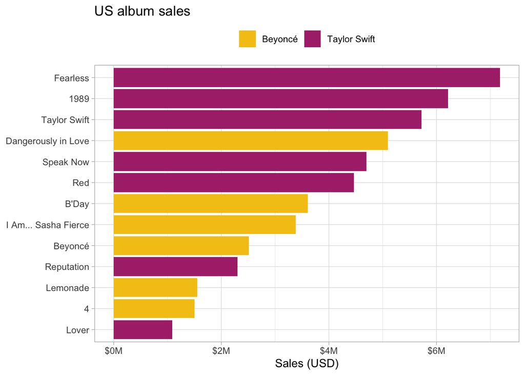

```r
sales |>
  filter(country == "US") |>
  mutate(title = fct_reorder(title, sales)) |>
  ggplot(aes(sales, title, fill = artist)) +
  geom_col() +
  scale_x_continuous(labels = label_dollar(scale = 1e-6, suffix = "M")) +
  scale_fill_manual(values = c("Beyoncé" = "#f5c518", "Taylor Swift" = "#ae3179")) +
  labs(title = "US album sales", x = "Sales (USD)", y = NULL, fill = NULL) +
  theme(legend.position = "top")
```

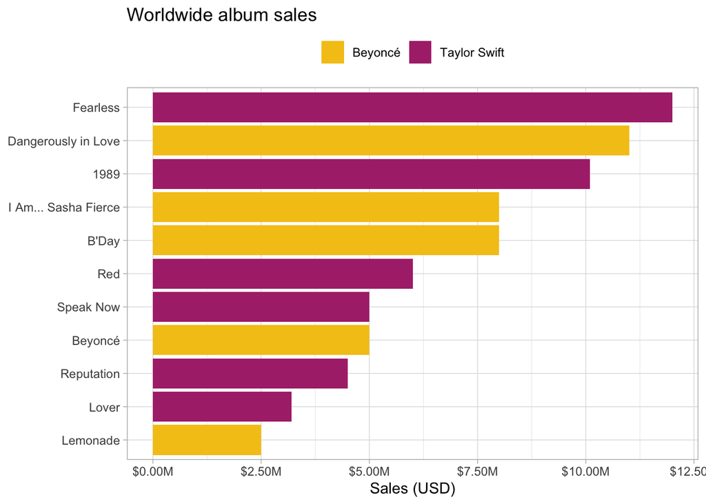

```r
sales |>
  filter(country %in% c("World", "WW")) |>
  mutate(title = fct_reorder(title, sales)) |>
  ggplot(aes(sales, title, fill = artist)) +
  geom_col() +
  scale_x_continuous(labels = label_dollar(scale = 1e-6, suffix = "M")) +
  scale_fill_manual(values = c("Beyoncé" = "#f5c518", "Taylor Swift" = "#ae3179")) +
  labs(title = "Worldwide album sales", x = "Sales (USD)", y = NULL, fill = NULL) +
  theme(legend.position = "top")
```

## 5 Part 2 — Taylor Swift TF-IDF per album

```r
release_dates <- charts |>
  distinct(album = title, released) |>
  mutate(
    album    = fct_recode(album, folklore = "Folklore", reputation = "Reputation"),
    released = str_remove(released, " \\(.*"),
    released = mdy(released)
  )
```

```r
taylor_swift_words <- taylor_swift_lyrics |>
  rename_all(str_to_lower) |>
  select(-artist) |>
  unnest_tokens(word, lyrics) |>
  anti_join(stop_words, by = "word") |>
  inner_join(release_dates, by = "album") |>
  mutate(album = fct_reorder(album, released))
```

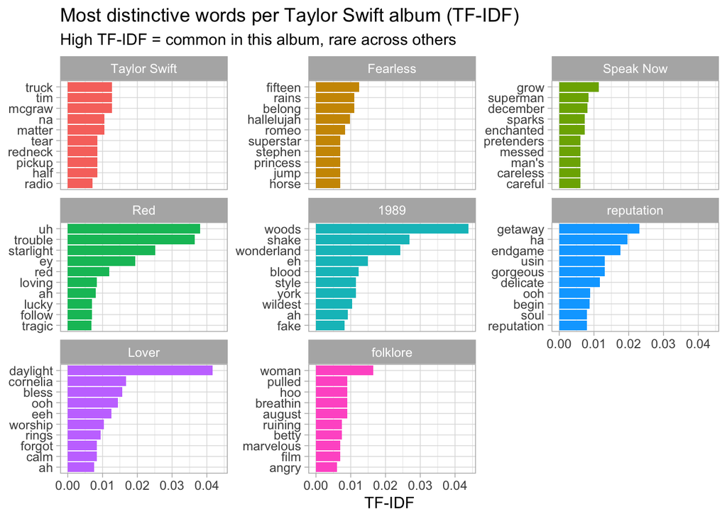

```r
taylor_swift_words |>
  count(album, word) |>
  bind_tf_idf(word, album, n) |>
  group_by(album) |>
  slice_max(tf_idf, n = 10, with_ties = FALSE) |>
  ungroup() |>
  mutate(word = reorder_within(word, tf_idf, album)) |>
  ggplot(aes(tf_idf, word, fill = album)) +
  geom_col(show.legend = FALSE) +
  facet_wrap(~album, scales = "free_y") +
  scale_y_reordered() +
  labs(title = "Most distinctive words per Taylor Swift album (TF-IDF)",
       subtitle = "High TF-IDF = common in this album, rare across others",
       x = "TF-IDF", y = NULL)
```

## 6 Part 3 — Weighted log-odds per album

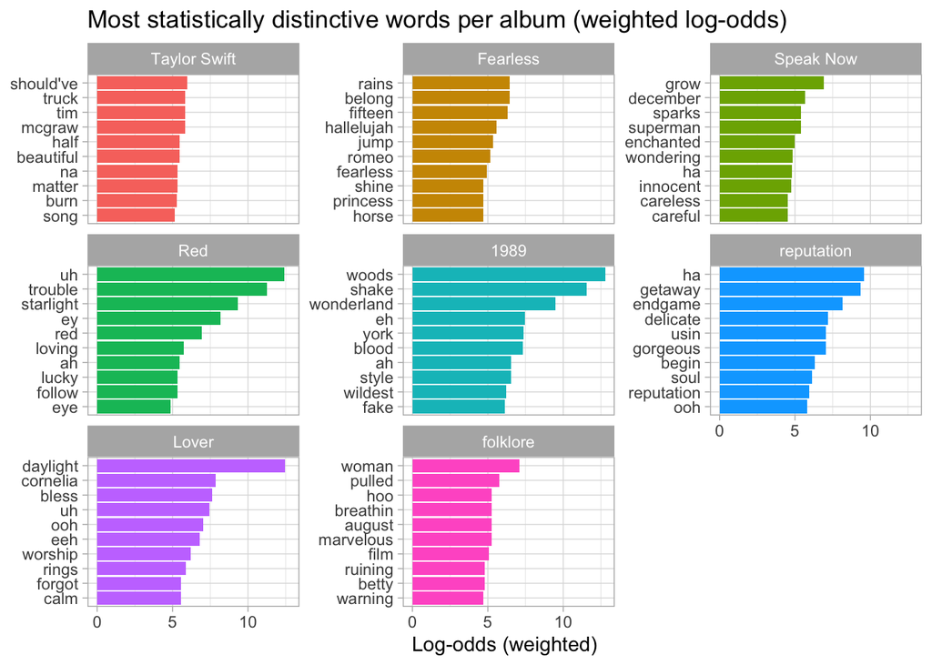

```r
taylor_swift_words |>
  count(album, word) |>
  bind_log_odds(album, word, n) |>
  group_by(album) |>
  slice_max(log_odds_weighted, n = 10, with_ties = FALSE) |>
  ungroup() |>
  mutate(word = reorder_within(word, log_odds_weighted, album)) |>
  ggplot(aes(log_odds_weighted, word, fill = album)) +
  geom_col(show.legend = FALSE) +
  facet_wrap(~album, scales = "free_y") +
  scale_y_reordered() +
  labs(title = "Most statistically distinctive words per album (weighted log-odds)",
       x = "Log-odds (weighted)", y = NULL)
```

## 7 Part 4 — Beyoncé vs Taylor Swift word contrast

```r
ts_clean <- taylor_swift_lyrics |>
  rename_all(str_to_lower) |>
  rename(song = title) |>
  select(-album)

bey_clean <- beyonce_lyrics |>
  select(artist = artist_name, song = song_name, lyrics = line)

artist_song_words <- bind_rows(ts_clean, bey_clean) |>
  unnest_tokens(word, lyrics) |>
  count(artist, song, word) |>
  anti_join(stop_words, by = "word")

by_artist_word <- artist_song_words |>
  group_by(artist, word) |>
  summarise(num_songs = n(), num_words = sum(n), .groups = "drop") |>
  mutate(pct_words = num_words / sum(num_words)) |>
  group_by(word) |>
  mutate(num_words_total = sum(num_words)) |>
  ungroup()
```

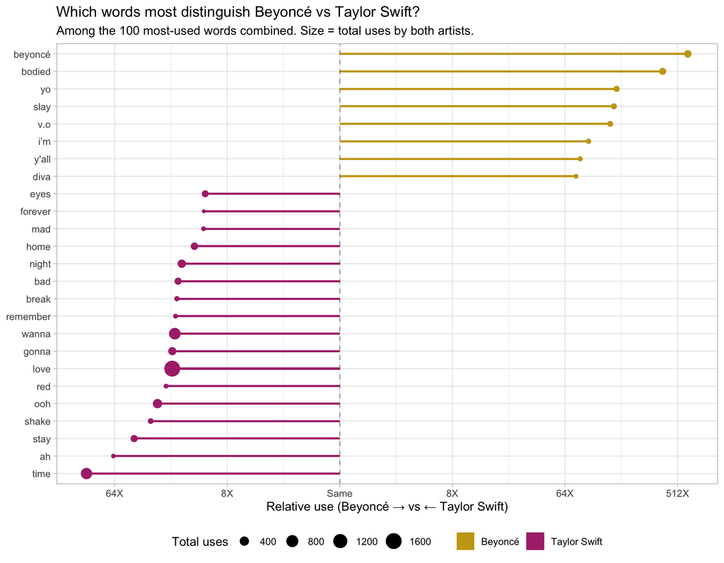

```r
x_breaks <- log(2 ^ seq(-6, 9, 3))
x_labels <- paste0(2 ^ abs(seq(-6, 9, 3)), "X")
x_labels[x_labels == "1X"] <- "Same"

by_artist_word |>
  bind_log_odds(artist, word, num_words) |>
  filter(artist == "Beyoncé") |>
  slice_max(num_words_total, n = 100, with_ties = FALSE) |>
  slice_max(abs(log_odds_weighted), n = 25, with_ties = FALSE) |>
  mutate(
    word      = fct_reorder(word, log_odds_weighted),
    direction = ifelse(log_odds_weighted > 0, "Beyoncé", "Taylor Swift")
  ) |>
  ggplot(aes(log_odds_weighted, word)) +
  geom_col(aes(fill = direction), width = 0.12) +
  geom_point(aes(size = num_words_total, color = direction)) +
  geom_vline(lty = 2, xintercept = 0, alpha = 0.35) +
  scale_x_continuous(breaks = x_breaks, labels = x_labels) +
  scale_color_manual(values = c("Beyoncé" = "#c8a415", "Taylor Swift" = "#ae3179")) +
  scale_fill_manual(values  = c("Beyoncé" = "#c8a415", "Taylor Swift" = "#ae3179")) +
  labs(
    title    = "Which words most distinguish Beyoncé vs Taylor Swift?",
    subtitle = "Among the 100 most-used words combined. Size = total uses by both artists.",
    x = "Relative use (Beyoncé → vs ← Taylor Swift)",
    y = NULL, color = NULL, fill = NULL, size = "Total uses"
  ) +
  theme(legend.position = "bottom")
```